# 期末資料探索

### 建立模型

預測下個月（2月份）是否購買的機率

```r
# 分割train與test
TR = subset(A_feb, spl)
TS = subset(A_feb, !spl)
```

```r
# 利用2:9的欄位來進行預測變數
# TR[,c(2:9, 11)] 指使用這些資料進行預測
# buy ~ .實際上就是使用TR[,2:9]的資料來預測TR[,11]
glm1 = glm(buy ~ ., TR[,c(2:9, 11)], family="binomial")
summary(glm1)
```

```
##
## Call:
## glm(formula = buy ~ ., family = "binomial", data = TR[, c(2:9,
##     11)])
##
## Deviance Residuals:
##     Min       1Q   Median       3Q      Max
## -3.8104  -0.8724  -0.7015   1.0355   1.8545
##
## Coefficients:
##               Estimate Std. Error z value Pr(>|z|)
## (Intercept) -1.345e+00  1.273e-01 -10.562  < 2e-16 ***
## r           -1.300e-02  8.983e-04 -14.475  < 2e-16 ***
## s            9.879e-03  9.091e-04  10.867  < 2e-16 ***
## f            2.917e-01  1.585e-02  18.408  < 2e-16 ***
## m           -1.751e-05  2.697e-05  -0.649 0.516076
## rev          3.549e-05  1.944e-05   1.825 0.067990 .
## raw         -2.362e-04  8.615e-05  -2.741 0.006120 **
## agea25      -5.243e-02  8.646e-02  -0.606 0.544191
## agea30      -9.929e-03  7.928e-02  -0.125 0.900333
## agea35       5.949e-02  7.848e-02   0.758 0.448452
## agea40       5.493e-02  8.062e-02   0.681 0.495676
## agea45      -4.559e-03  8.407e-02  -0.054 0.956750
## agea50      -1.379e-02  9.291e-02  -0.148 0.882027
## agea55       2.147e-01  1.105e-01   1.942 0.052147 .
## agea60       1.204e-01  1.193e-01   1.009 0.312755
## agea65       2.020e-01  1.029e-01   1.964 0.049552 *
## agena       -1.361e-01  1.484e-01  -0.917 0.359356
## area106      6.295e-02  1.340e-01   0.470 0.638411
## area110     -6.622e-02  1.062e-01  -0.623 0.533034
## area114      1.612e-01  1.132e-01   1.424 0.154306
## area115      3.697e-01  9.884e-02   3.740 0.000184 ***
## area221      2.766e-01  9.953e-02   2.779 0.005454 **
## areaOthers   6.446e-02  1.064e-01   0.606 0.544692
## areaUnknown -2.758e-03  1.246e-01  -0.022 0.982339
## ---
## Signif. codes:  0 '***' 0.001 '**' 0.01 '*' 0.05 '.' 0.1 ' ' 1
##
## (Dispersion parameter for binomial family taken to be 1)
##
##     Null deviance: 27630  on 20008  degrees of freedom
## Residual deviance: 23269  on 19985  degrees of freedom
## AIC: 23317
##
## Number of Fisher Scoring iterations: 5
```

```r
# 建立預測模型後利用test 資料進行預測，並取得機率
pred =  predict(glm1, TS, type="response")
# 建立混淆矩陣，觀察auc
cm = table(actual = TS$buy, predict = pred > 0.5); cm
```

```
##        predict
## actual  FALSE TRUE
##   FALSE  3727  875
##   TRUE   1679 2294
```

```r
acc.ts = cm %>% {sum(diag(.))/sum(.)}; acc.ts          # 0.69998
```

```
## [1] 0.7021574
```

```r
colAUC(pred, TS$buy)
```

```
##                     [,1]
## FALSE vs. TRUE 0.7533763
```

- 預測下個月購買的金額

A2 為A_feb的與金額相關的資料取log後的結果

```r
TR2 = subset(A2, spl2)
TS2 = subset(A2, !spl2)
```

```r
# 利用2:6,8:10的欄位來進行預測變數
# TR2[,c(2:6,8:10)] 指使用這些資料進行預測
# amount ~ .實際上就是使用TR[,2:6,8:9]的資料來預測TR[,10]
lm1 = lm(amount ~ ., TR2[,c(2:6,8:10)])
summary(lm1)
```

```
##
## Call:
## lm(formula = amount ~ ., data = TR2[, c(2:6, 8:10)])
##
## Residuals:
##     Min      1Q  Median      3Q     Max
## -1.8577 -0.2286  0.0478  0.2845  1.6562
##
## Coefficients:
##               Estimate Std. Error t value Pr(>|t|)
## (Intercept)  1.186e+00  5.066e-02  23.419  < 2e-16 ***
## r           -2.237e-06  3.108e-04  -0.007 0.994258
## s            2.023e-04  3.135e-04   0.645 0.518706
## f            2.617e-02  1.836e-03  14.255  < 2e-16 ***
## m            5.149e-01  3.757e-02  13.704  < 2e-16 ***
## rev          2.826e-02  3.640e-02   0.776 0.437625
## agea25       4.983e-02  2.484e-02   2.006 0.044892 *
## agea30       1.061e-01  2.268e-02   4.676 2.97e-06 ***
## agea35       1.185e-01  2.239e-02   5.292 1.23e-07 ***
## agea40       1.122e-01  2.293e-02   4.892 1.02e-06 ***
## agea45       9.055e-02  2.379e-02   3.806 0.000142 ***
## agea50       7.537e-02  2.617e-02   2.881 0.003979 **
## agea55       6.300e-02  3.098e-02   2.034 0.041994 *
## agea60       3.365e-02  3.156e-02   1.066 0.286397
## agea65      -3.729e-02  2.773e-02  -1.345 0.178723
## agena        1.141e-01  3.974e-02   2.871 0.004105 **
## area106      8.737e-02  4.351e-02   2.008 0.044679 *
## area110      2.787e-02  3.618e-02   0.770 0.441146
## area114     -1.565e-02  3.837e-02  -0.408 0.683367
## area115     -4.594e-03  3.355e-02  -0.137 0.891100
## area221      7.869e-03  3.379e-02   0.233 0.815849
## areaOthers   1.709e-02  3.582e-02   0.477 0.633230
## areaUnknown -3.970e-03  3.981e-02  -0.100 0.920571
## ---
## Signif. codes:  0 '***' 0.001 '**' 0.01 '*' 0.05 '.' 0.1 ' ' 1
##
## Residual standard error: 0.4227 on 9247 degrees of freedom
## Multiple R-squared:  0.2856, Adjusted R-squared:  0.2839
## F-statistic: 168.1 on 22 and 9247 DF,  p-value: < 2.2e-16
```

誤差計算

```r
r2.tr = summary(lm1)$r.sq
SST = sum((TS2$amount - mean(TR2$amount))^ 2)
SSE = sum((predict(lm1, TS2) -  TS2$amount)^2)
r2.ts = 1 - (SSE/SST)
c(r2.tr, r2.ts)
```

```
## [1] 0.2856422 0.2714954
```

#### 預測模型

重新讀取原本4個月的資料，進行模型預測

```r
load("./X.rdata")
d0 = max(X$date) + 1
# 建立12月到2月的交易資料
B = X %>%
  filter(date >= as.Date("2000-12-01")) %>%
  mutate(days = as.integer(difftime(d0, date, units="days"))) %>%
  group_by(cust) %>% summarise(
    r = min(days),      # recency
    s = max(days),      # seniority
    f = n(),            # frquency
    m = mean(total),    # monetary
    rev = sum(total),   # total revenue contribution
    raw = sum(gross),   # total gross profit contribution
    age = age[1],       # age group
    area = area[1],     # area code
  ) %>% data.frame      # 28584
nrow(B)
```

```
## [1] 28531
```

```r
# 預測回購紀機率
B$Buy = predict(glm1, B, type="response")

B2 = B %>% mutate_at(c("m","rev"), log10)
# 預測回購金額
B$Rev = 10^predict(lm1, B2)
```

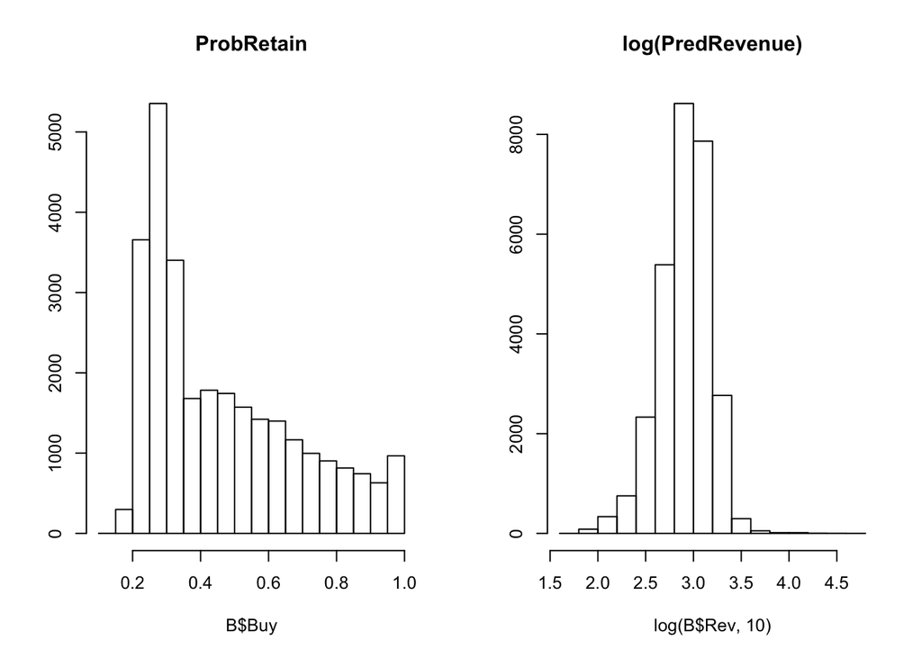

```r
par(mfrow=c(1,2), cex=0.8)
hist(B$Buy,main="ProbRetain", ylab="")
hist(log(B$Rev,10),main="log(PredRevenue)", ylab="")
```

###計算顧客終生價值（CLV）

```r
g = 0.5   # (稅前)獲利率
N = 5     # 期數 = 5
d = 0.1   # 利率 = 10%
B$CLV = g * B$Rev * rowSums(sapply(
  0:N, function(i) (B$Buy/(1+d))^i ) )

summary(B$CLV)
```

```
##      Min.   1st Qu.    Median      Mean   3rd Qu.      Max.
##     43.73    441.77    721.19   1017.31   1168.55 106202.36
```

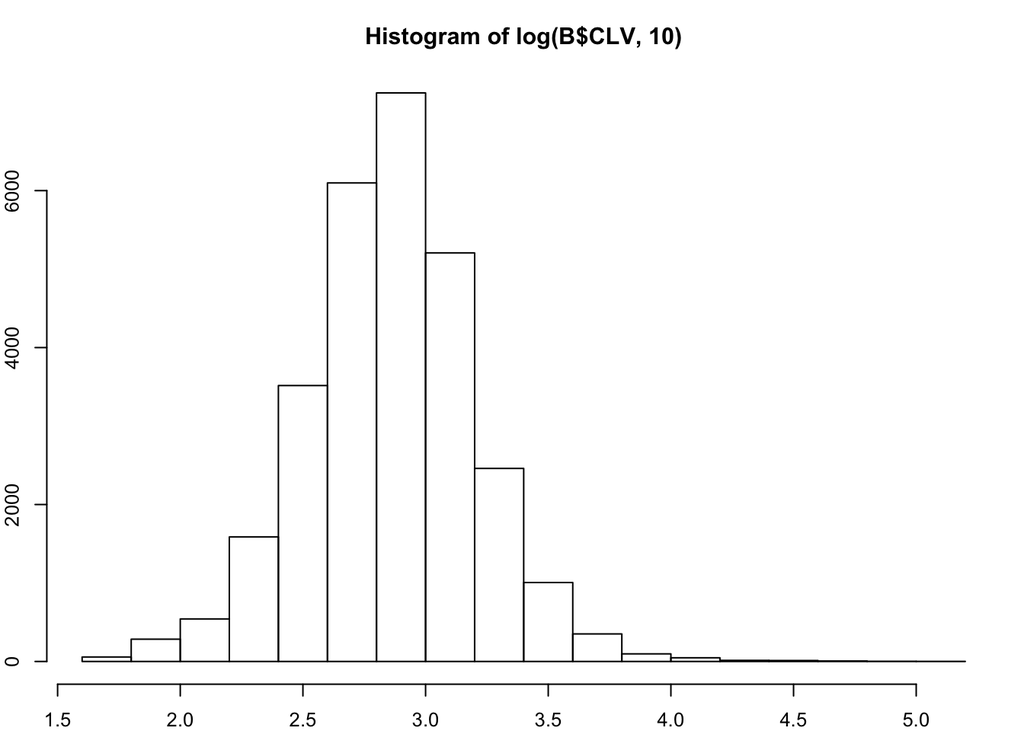

```r
par(mar=c(2,2,3,1), cex=0.8)
hist(log(B$CLV,10), xlab="", ylab="")
```

## 比較各族群的價值

```r
# 各族群的平均營收貢獻、保留機率、終生價值
B = merge(B,A[,c(1,12)],by="cust")
sapply(B[,10:12], tapply, B$keams, mean)
```

```
##         Buy       Rev       CLV
## 1 0.8881599 2315.4874 4751.2491
## 2 0.2807461  688.6710  463.6830
## 3 0.3438747  750.3091  556.7253
## 4 0.3840061 1761.0830 1408.5802
## 5 0.5962539  862.4012 1030.2161
```

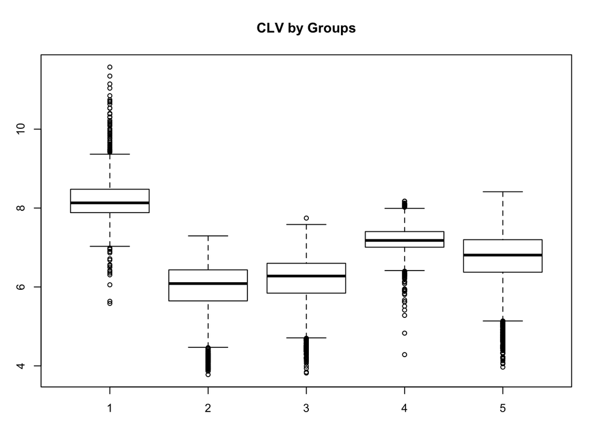

```r
par(mar=c(3,3,4,2), cex=0.8)
boxplot(log(CLV)~keams, B, main="CLV by Groups")
```

這些地區可以表示成未來可以加強行銷重點

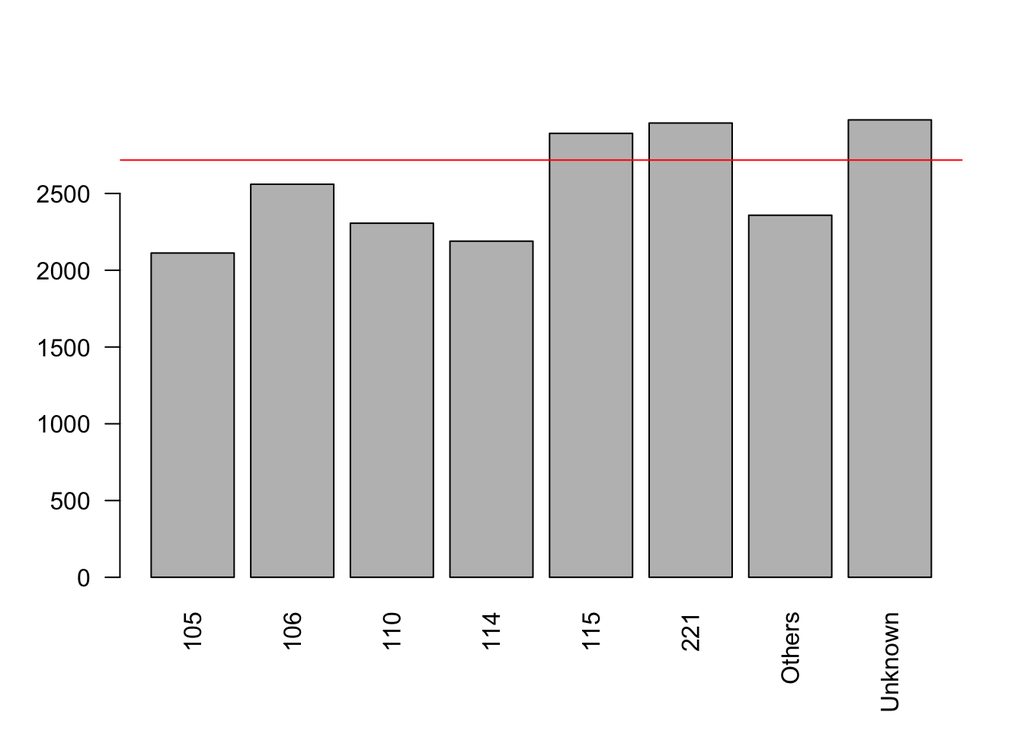

```r
# 顯示各地區平均購買的金額
tapply(A_feb$rev, A_feb$area, mean) %>% barplot(las=2)
abline(h = mean(A_feb$rev), col='red')
```

可以了解資料中的分群中都買什麼東西， 與其他兩個群組有無重複（有重複！） 如果有，可以進行假設商品，並擬定行銷計畫 把群組都當作目標客群

```r
# 整理商品資料成一筆
mix = merge(Z,A[,c(1,11,12)],by="cust")

P = mix %>% group_by(keams,prod) %>% summarise(
  num = n(),
  price = price[1]/qty[1]
) %>% top_n(n = 10,wt = num)
# P$prod = factor(P$prod)
# levels(P$prod) = 1:27
# P$prod
```

```r
library(reshape2)
library(d3heatmap)

dtm = dcast(P,formula = keams~prod,value.var = "price")
row.names(dtm) = dtm$keams
termDocMatrix = as.matrix(dtm[,-1])
termDocMatrix[is.na(termDocMatrix)] = 0
d3heatmap(termDocMatrix,colors = "Blues")
```

[interactive chart not shown]

```r
# 取log後的結果
termDocMatrix = log(termDocMatrix)
termDocMatrix[termDocMatrix == -Inf] = 0
d3heatmap(termDocMatrix,colors = "Greens",cexRow = 0.7)
```

[interactive chart not shown]

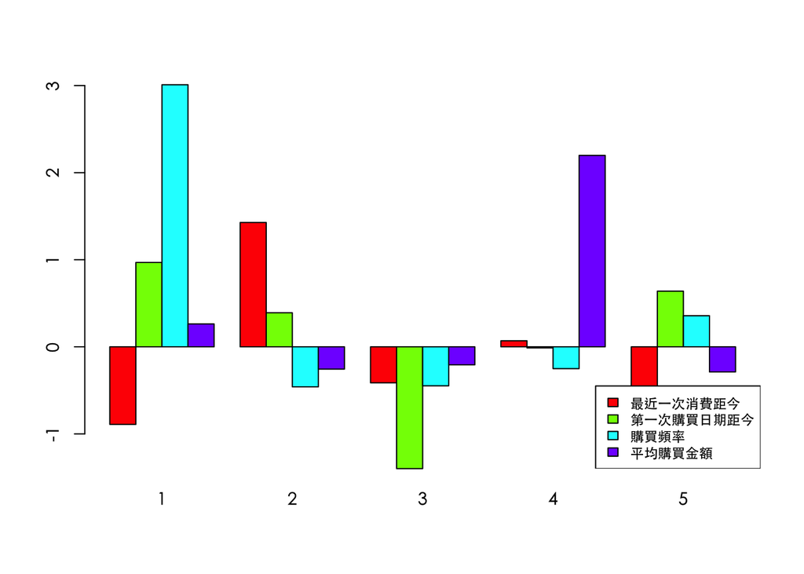

```r
A$logm = log(A$m)
par(cex = 0.9)
par(family="黑體-繁 中黑")

A[,c(2:5)] %>% scale %>% as.data.frame %>%  split(.,A$keams) %>% sapply(colMeans) %>%
  barplot(beside=T, col=rainbow(4))
legend("bottomright", c("最近一次消費距今", "第一次購買日期距今", "購買頻率","平均購買金額"),fill=rainbow(4),cex=0.8)
```

第2群顧客奇怪的是購買商品數量較雜 購買商品種類繁多，但是都沒有一定的趨勢

```r
mix %>% filter(cut2_4_7==2) %>% group_by(prod) %>% summarise(n = n()) %>% arrange(desc(n))
```

```
## # A tibble: 9,586 x 2
##    prod              n
##    <chr>         <int>
##  1 4714981010038   521
##  2 4711856000125   161
##  3 4710036003581   156
##  4 4710908110232   145
##  5 4710363352000   128
##  6 4710265849066   127
##  7 4710114128038   125
##  8 0037000329206   110
##  9 0037000440147   108
## 10 4710114362029   106
## # … with 9,576 more rows
```

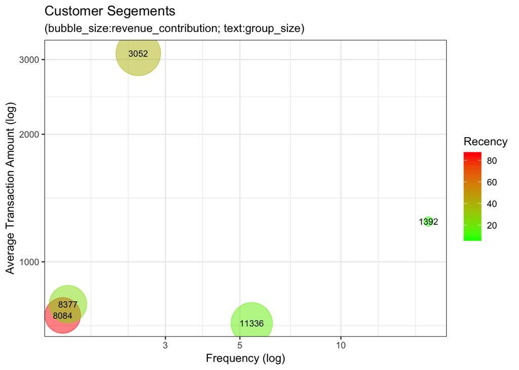

```r
group_by(A, keams) %>% summarise(
  recent=mean(r),
  freq=mean(f),
  money=mean(m),
  size=n() ) %>%
  mutate( revenue = size*money/1000 )  %>%
  filter(size > 1) %>%
  ggplot(aes(x=freq, y=money)) +
  geom_point(aes(size=revenue, col=recent),alpha=0.5) +
  scale_size(range=c(4,20)) +
  scale_color_gradient(low="green",high="red") +
  scale_x_log10() + scale_y_log10() +
  geom_text(aes(label = size ),size=3) +
  theme_bw() + guides(size=F) +
  labs(title="Customer Segements",
       subtitle="(bubble_size:revenue_contribution; text:group_size)",
       color="Recency") +
  xlab("Frequency (log)") + ylab("Average Transaction Amount (log)")
```

畫出顧客分群

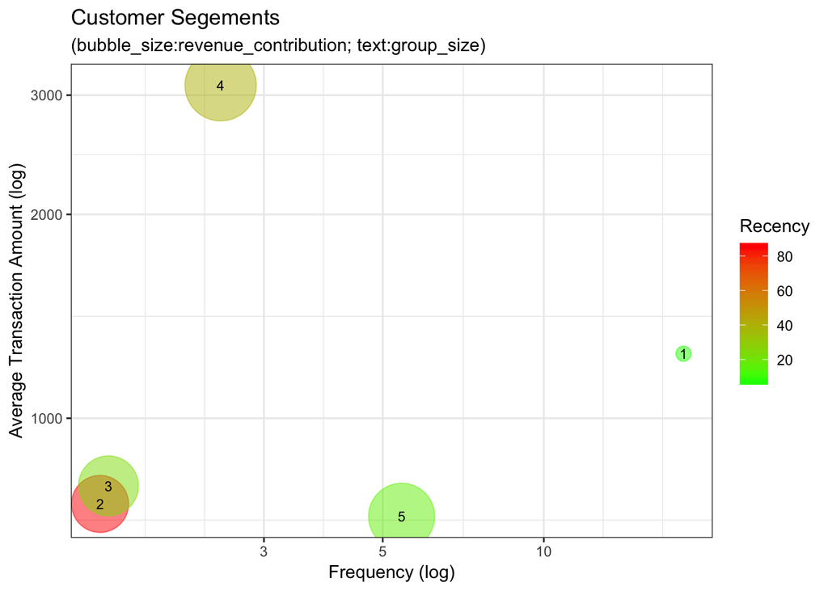

```r
group_by(A, keams) %>% summarise(
  recent=mean(r),
  freq=mean(f),
  money=mean(m),
  size=n() ) %>%
  mutate( revenue = size*money/1000 )  %>%
  filter(size > 1) %>%
  ggplot(aes(x=freq, y=money)) +
  geom_point(aes(size=revenue, col=recent),alpha=0.5) +
  scale_size(range=c(4,20)) +
  scale_color_gradient(low="green",high="red") +
  scale_x_log10() + scale_y_log10() +
  geom_text(aes(label = keams ),size=3) +
  theme_bw() + guides(size=F) +
  labs(title="Customer Segements",
       subtitle="(bubble_size:revenue_contribution; text:group_size)",
       color="Recency") +
  xlab("Frequency (log)") + ylab("Average Transaction Amount (log)")
```

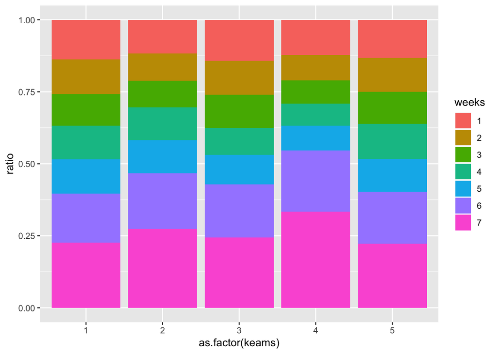

```r
mix = merge(Z,A[,c(1,12)],by = "cust")
mix$weeks = format(mix$date,"%u")
group_by(mix,keams,weeks) %>%
  summarise(count = n()) %>%
  group_by(keams) %>%
  mutate(sum = sum(count),ratio = count/sum) %>%
  ggplot(aes(x=as.factor(keams),y = ratio,fill = weeks)) + geom_bar(stat = "identity")
```

了解客戶這4個月最常來的星期 並且計算顧客所屬群組的常去星期幾買東西的總和

```r
A_often_come = group_by(mix,cust,weeks) %>%
  summarise(
    count = n(),
    label = keams[1]
  ) %>% group_by(cust) %>% top_n(1,wt = count)

table(A_often_come$weeks,A_often_come$label) %>% as.data.frame.matrix() %>% d3heatmap::d3heatmap(colors = "Greens")
```

[interactive chart not shown]

```r
X %>% group_by(date) %>% summarise(
  count = n()
) %>% arrange(desc(count))
```

```
## # A tibble: 120 x 2
##    date       count
##    <date>     <int>
##  1 2001-01-22  2225
##  2 2001-01-21  2070
##  3 2000-11-26  1780
##  4 2000-11-25  1704
##  5 2000-11-12  1651
##  6 2000-12-17  1643
##  7 2001-01-14  1635
##  8 2000-12-31  1631
##  9 2000-11-05  1580
## 10 2001-01-20  1579
## # … with 110 more rows
```

```r
temp3 = Z %>% group_by(prod) %>% summarise(s = sum(qty))
arrange(temp3, s)
```

```
## # A tibble: 23,789 x 2
##    prod              s
##    <chr>         <dbl>
##  1 0002884011363     1
##  2 0011797210039     1
##  3 0015000761707     1
##  4 0026333006366     1
##  5 0026333006380     1
##  6 0026333006397     1
##  7 0026333007905     1
##  8 0028851030137     1
##  9 0034223097165     1
## 10 0035496001323     1
## # … with 23,779 more rows
```

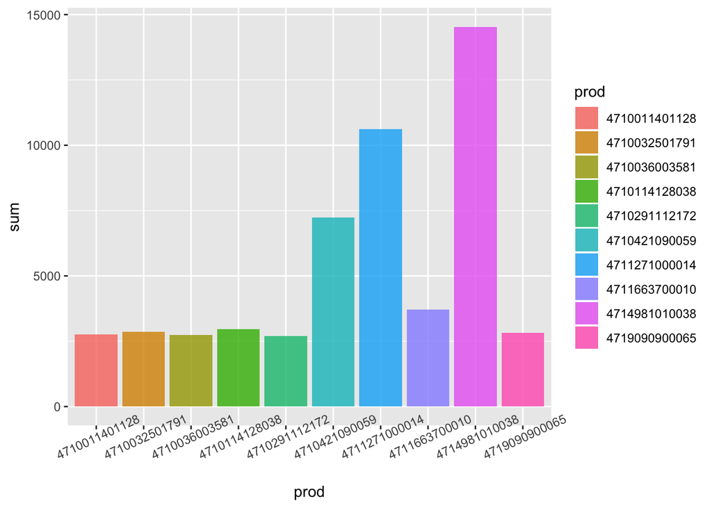

```r
product_z = Z %>% group_by(date,prod,area) %>%
  summarise(
    sum = sum(qty)
  )
product_top = product_z %>% group_by(prod) %>% summarise(
  sum = sum(sum)
) %>% arrange(desc(sum))
product_top %>% head(n = 10) %>% ggplot(aes(x = prod,y = sum,fill=prod)) + geom_bar(stat = "identity",alpha = 0.8) +
  theme(axis.text.x = element_text(angle = 25))
```

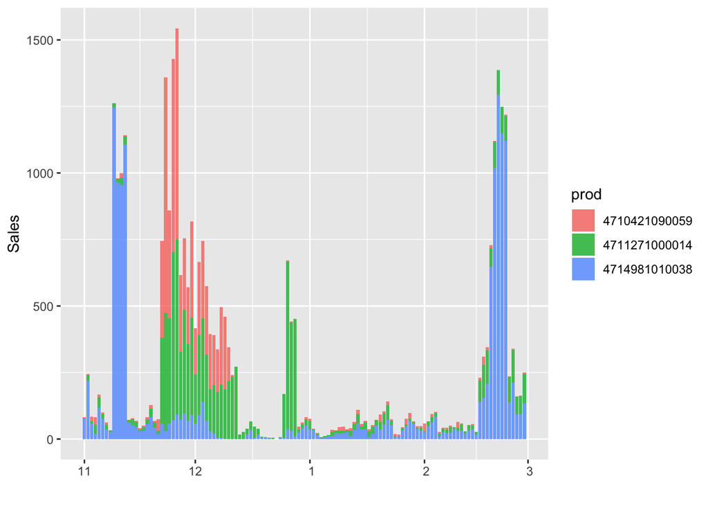

```r
product_top3 = product_z %>% filter(prod %in% c("4714981010038","4710421090059","4711271000014")) %>% group_by(date,prod) %>% summarise(
  sum = sum(sum)
)

ggplot(product_top3,aes(x = date,y = sum,fill=prod)) + geom_bar(stat = "identity",alpha = 0.8) + labs(y = "Sales", x = "")
```

```r
library(reshape2)
product_top3 %>% mutate(weeks = format(date,"%u")) %>% group_by(prod,weeks) %>% summarise(sum = sum(sum)) %>%
  acast(formula = prod~weeks,value.var = "sum") %>% d3heatmap::d3heatmap(col="PiYG",Colv = F)
```

[interactive chart not shown]